# Risk Factor Analysis

## Outcome Variable

**Outcome Variable:** whz

## Predictor Variables

**Intervention Variable:** single

**Adjustment Set:**

- arm
- W_mage
- W_fage
- meducyrs
- feducyrs
- W_mhtcm
- W_mwtkg
- W_mbmi
- delta_W_mage
- delta_W_fage
- delta_meducyrs
- delta_feducyrs
- delta_W_mhtcm
- delta_W_mwtkg
- delta_W_mbmi

## Stratifying Variables

The analysis was stratified on these variable(s):

- agecat
- studyid
- country

## Data Summary

| agecat | studyid | country | single | n_cell | n |
| --- | --- | --- | --- | --- | --- |
| Birth | ki0047075b-MAL-ED | BANGLADESH | 0 | 241 | 241 |
| Birth | ki0047075b-MAL-ED | BANGLADESH | 1 | 0 | 241 |
| Birth | ki0047075b-MAL-ED | BRAZIL | 0 | 159 | 183 |
| Birth | ki0047075b-MAL-ED | BRAZIL | 1 | 24 | 183 |
| Birth | ki0047075b-MAL-ED | INDIA | 0 | 202 | 202 |
| Birth | ki0047075b-MAL-ED | INDIA | 1 | 0 | 202 |
| Birth | ki0047075b-MAL-ED | NEPAL | 0 | 168 | 168 |
| Birth | ki0047075b-MAL-ED | NEPAL | 1 | 0 | 168 |
| Birth | ki0047075b-MAL-ED | PERU | 0 | 247 | 279 |
| Birth | ki0047075b-MAL-ED | PERU | 1 | 32 | 279 |
| Birth | ki0047075b-MAL-ED | SOUTH AFRICA | 0 | 145 | 258 |
| Birth | ki0047075b-MAL-ED | SOUTH AFRICA | 1 | 113 | 258 |
| Birth | ki0047075b-MAL-ED | TANZANIA, UNITED REPUBLIC OF | 0 | 112 | 118 |
| Birth | ki0047075b-MAL-ED | TANZANIA, UNITED REPUBLIC OF | 1 | 6 | 118 |
| Birth | ki1119695-PROBIT | BELARUS | 0 | 13286 | 13824 |
| Birth | ki1119695-PROBIT | BELARUS | 1 | 538 | 13824 |
| Birth | ki1126311-ZVITAMBO | ZIMBABWE | 0 | 12064 | 12863 |
| Birth | ki1126311-ZVITAMBO | ZIMBABWE | 1 | 799 | 12863 |
| Birth | ki1135781-COHORTS | GUATEMALA | 0 | 654 | 691 |
| Birth | ki1135781-COHORTS | GUATEMALA | 1 | 37 | 691 |
| Birth | ki1135781-COHORTS | INDIA | 0 | 4456 | 4463 |
| Birth | ki1135781-COHORTS | INDIA | 1 | 7 | 4463 |
| Birth | ki1135781-COHORTS | PHILIPPINES | 0 | 2789 | 2860 |
| Birth | ki1135781-COHORTS | PHILIPPINES | 1 | 71 | 2860 |
| 6 months | ki0047075b-MAL-ED | BANGLADESH | 0 | 241 | 241 |
| 6 months | ki0047075b-MAL-ED | BANGLADESH | 1 | 0 | 241 |
| 6 months | ki0047075b-MAL-ED | BRAZIL | 0 | 179 | 209 |
| 6 months | ki0047075b-MAL-ED | BRAZIL | 1 | 30 | 209 |
| 6 months | ki0047075b-MAL-ED | INDIA | 0 | 234 | 234 |
| 6 months | ki0047075b-MAL-ED | INDIA | 1 | 0 | 234 |
| 6 months | ki0047075b-MAL-ED | NEPAL | 0 | 236 | 236 |
| 6 months | ki0047075b-MAL-ED | NEPAL | 1 | 0 | 236 |
| 6 months | ki0047075b-MAL-ED | PERU | 0 | 240 | 273 |
| 6 months | ki0047075b-MAL-ED | PERU | 1 | 33 | 273 |
| 6 months | ki0047075b-MAL-ED | SOUTH AFRICA | 0 | 140 | 254 |
| 6 months | ki0047075b-MAL-ED | SOUTH AFRICA | 1 | 114 | 254 |
| 6 months | ki0047075b-MAL-ED | TANZANIA, UNITED REPUBLIC OF | 0 | 239 | 247 |
| 6 months | ki0047075b-MAL-ED | TANZANIA, UNITED REPUBLIC OF | 1 | 8 | 247 |
| 6 months | ki1066203-TanzaniaChild2 | TANZANIA, UNITED REPUBLIC OF | 0 | 1834 | 2012 |
| 6 months | ki1066203-TanzaniaChild2 | TANZANIA, UNITED REPUBLIC OF | 1 | 178 | 2012 |
| 6 months | ki1112895-Guatemala BSC | GUATEMALA | 0 | 248 | 277 |
| 6 months | ki1112895-Guatemala BSC | GUATEMALA | 1 | 29 | 277 |
| 6 months | ki1119695-PROBIT | BELARUS | 0 | 15114 | 15757 |
| 6 months | ki1119695-PROBIT | BELARUS | 1 | 643 | 15757 |
| 6 months | ki1126311-ZVITAMBO | ZIMBABWE | 0 | 7746 | 8234 |
| 6 months | ki1126311-ZVITAMBO | ZIMBABWE | 1 | 488 | 8234 |
| 6 months | ki1135781-COHORTS | GUATEMALA | 0 | 827 | 894 |
| 6 months | ki1135781-COHORTS | GUATEMALA | 1 | 67 | 894 |
| 6 months | ki1135781-COHORTS | INDIA | 0 | 4955 | 4964 |
| 6 months | ki1135781-COHORTS | INDIA | 1 | 9 | 4964 |
| 6 months | ki1135781-COHORTS | PHILIPPINES | 0 | 2606 | 2674 |
| 6 months | ki1135781-COHORTS | PHILIPPINES | 1 | 68 | 2674 |
| 24 months | ki0047075b-MAL-ED | BANGLADESH | 0 | 212 | 212 |
| 24 months | ki0047075b-MAL-ED | BANGLADESH | 1 | 0 | 212 |
| 24 months | ki0047075b-MAL-ED | BRAZIL | 0 | 148 | 169 |
| 24 months | ki0047075b-MAL-ED | BRAZIL | 1 | 21 | 169 |
| 24 months | ki0047075b-MAL-ED | INDIA | 0 | 225 | 225 |
| 24 months | ki0047075b-MAL-ED | INDIA | 1 | 0 | 225 |
| 24 months | ki0047075b-MAL-ED | NEPAL | 0 | 228 | 228 |
| 24 months | ki0047075b-MAL-ED | NEPAL | 1 | 0 | 228 |
| 24 months | ki0047075b-MAL-ED | PERU | 0 | 176 | 201 |
| 24 months | ki0047075b-MAL-ED | PERU | 1 | 25 | 201 |
| 24 months | ki0047075b-MAL-ED | SOUTH AFRICA | 0 | 131 | 238 |
| 24 months | ki0047075b-MAL-ED | SOUTH AFRICA | 1 | 107 | 238 |
| 24 months | ki0047075b-MAL-ED | TANZANIA, UNITED REPUBLIC OF | 0 | 208 | 214 |
| 24 months | ki0047075b-MAL-ED | TANZANIA, UNITED REPUBLIC OF | 1 | 6 | 214 |
| 24 months | ki1066203-TanzaniaChild2 | TANZANIA, UNITED REPUBLIC OF | 0 | 6 | 6 |
| 24 months | ki1066203-TanzaniaChild2 | TANZANIA, UNITED REPUBLIC OF | 1 | 0 | 6 |
| 24 months | ki1119695-PROBIT | BELARUS | 0 | 3829 | 3971 |
| 24 months | ki1119695-PROBIT | BELARUS | 1 | 142 | 3971 |
| 24 months | ki1126311-ZVITAMBO | ZIMBABWE | 0 | 379 | 422 |
| 24 months | ki1126311-ZVITAMBO | ZIMBABWE | 1 | 43 | 422 |
| 24 months | ki1135781-COHORTS | GUATEMALA | 0 | 932 | 1021 |
| 24 months | ki1135781-COHORTS | GUATEMALA | 1 | 89 | 1021 |
| 24 months | ki1135781-COHORTS | INDIA | 0 | 3717 | 3726 |
| 24 months | ki1135781-COHORTS | INDIA | 1 | 9 | 3726 |
| 24 months | ki1135781-COHORTS | PHILIPPINES | 0 | 2361 | 2420 |
| 24 months | ki1135781-COHORTS | PHILIPPINES | 1 | 59 | 2420 |

The following strata were considered:

- agecat: 24 months, studyid: ki0047075b-MAL-ED, country: BANGLADESH
- agecat: 24 months, studyid: ki0047075b-MAL-ED, country: BRAZIL
- agecat: 24 months, studyid: ki0047075b-MAL-ED, country: INDIA
- agecat: 24 months, studyid: ki0047075b-MAL-ED, country: NEPAL
- agecat: 24 months, studyid: ki0047075b-MAL-ED, country: PERU
- agecat: 24 months, studyid: ki0047075b-MAL-ED, country: SOUTH AFRICA
- agecat: 24 months, studyid: ki0047075b-MAL-ED, country: TANZANIA, UNITED REPUBLIC OF
- agecat: 24 months, studyid: ki1066203-TanzaniaChild2, country: TANZANIA, UNITED REPUBLIC OF
- agecat: 24 months, studyid: ki1119695-PROBIT, country: BELARUS
- agecat: 24 months, studyid: ki1126311-ZVITAMBO, country: ZIMBABWE
- agecat: 24 months, studyid: ki1135781-COHORTS, country: GUATEMALA
- agecat: 24 months, studyid: ki1135781-COHORTS, country: INDIA
- agecat: 24 months, studyid: ki1135781-COHORTS, country: PHILIPPINES
- agecat: 6 months, studyid: ki0047075b-MAL-ED, country: BANGLADESH
- agecat: 6 months, studyid: ki0047075b-MAL-ED, country: BRAZIL
- agecat: 6 months, studyid: ki0047075b-MAL-ED, country: INDIA
- agecat: 6 months, studyid: ki0047075b-MAL-ED, country: NEPAL
- agecat: 6 months, studyid: ki0047075b-MAL-ED, country: PERU
- agecat: 6 months, studyid: ki0047075b-MAL-ED, country: SOUTH AFRICA
- agecat: 6 months, studyid: ki0047075b-MAL-ED, country: TANZANIA, UNITED REPUBLIC OF
- agecat: 6 months, studyid: ki1066203-TanzaniaChild2, country: TANZANIA, UNITED REPUBLIC OF
- agecat: 6 months, studyid: ki1112895-Guatemala BSC, country: GUATEMALA
- agecat: 6 months, studyid: ki1119695-PROBIT, country: BELARUS
- agecat: 6 months, studyid: ki1126311-ZVITAMBO, country: ZIMBABWE
- agecat: 6 months, studyid: ki1135781-COHORTS, country: GUATEMALA
- agecat: 6 months, studyid: ki1135781-COHORTS, country: INDIA
- agecat: 6 months, studyid: ki1135781-COHORTS, country: PHILIPPINES
- agecat: Birth, studyid: ki0047075b-MAL-ED, country: BANGLADESH
- agecat: Birth, studyid: ki0047075b-MAL-ED, country: BRAZIL
- agecat: Birth, studyid: ki0047075b-MAL-ED, country: INDIA
- agecat: Birth, studyid: ki0047075b-MAL-ED, country: NEPAL
- agecat: Birth, studyid: ki0047075b-MAL-ED, country: PERU
- agecat: Birth, studyid: ki0047075b-MAL-ED, country: SOUTH AFRICA
- agecat: Birth, studyid: ki0047075b-MAL-ED, country: TANZANIA, UNITED REPUBLIC OF
- agecat: Birth, studyid: ki1119695-PROBIT, country: BELARUS
- agecat: Birth, studyid: ki1126311-ZVITAMBO, country: ZIMBABWE
- agecat: Birth, studyid: ki1135781-COHORTS, country: GUATEMALA
- agecat: Birth, studyid: ki1135781-COHORTS, country: INDIA
- agecat: Birth, studyid: ki1135781-COHORTS, country: PHILIPPINES

### Dropped Strata

- agecat: Birth, studyid: ki0047075b-MAL-ED, country: BANGLADESH
- agecat: Birth, studyid: ki0047075b-MAL-ED, country: INDIA
- agecat: Birth, studyid: ki0047075b-MAL-ED, country: NEPAL
- agecat: 6 months, studyid: ki0047075b-MAL-ED, country: BANGLADESH
- agecat: 6 months, studyid: ki0047075b-MAL-ED, country: INDIA
- agecat: 6 months, studyid: ki0047075b-MAL-ED, country: NEPAL
- agecat: 24 months, studyid: ki0047075b-MAL-ED, country: BANGLADESH
- agecat: 24 months, studyid: ki0047075b-MAL-ED, country: INDIA
- agecat: 24 months, studyid: ki0047075b-MAL-ED, country: NEPAL
- agecat: 24 months, studyid: ki1066203-TanzaniaChild2, country: TANZANIA, UNITED REPUBLIC OF

## Methods Detail

We’re interested in the causal parameters $E[Y_a]$ for all values of $a \in \mathcal{A}$. These parameters represent the mean outcome if, possibly contrary to fact, we intervened to set all units to have $A=a$. Under the randomization and positivity assumptions, these are identified by the statistical parameters $\psi_a=E_W[E_{Y|A,W}(Y|A=a,W)]$. In addition, we’re interested in the mean of $Y$, $E[Y]$ under no intervention (the observed mean). We will estimate these parameters by using SuperLearner to fit the relevant likelihood factors – $E_{Y|A,W}(Y|A=a,W)$ and $p(A=a|W)$, and then updating our likelihood fit using a joint TMLE.

For unadjusted analyses ($W=\{\}$), initial likelihoods were estimated using Lrnr_glm to estimate the simple $E(Y|A)$ and Lrnr_mean to estimate $p(A)$. For adjusted analyses, a small library containing Lrnr_glmnet, Lrnr_xgboost, and Lrnr_mean was used.

# Results Detail

## Results Plots

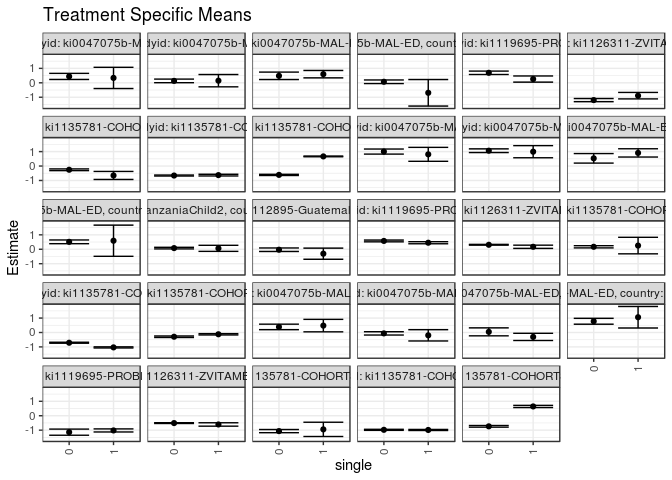

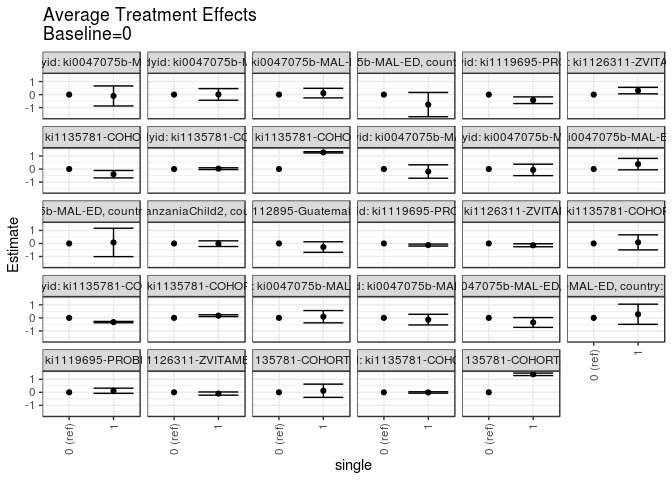

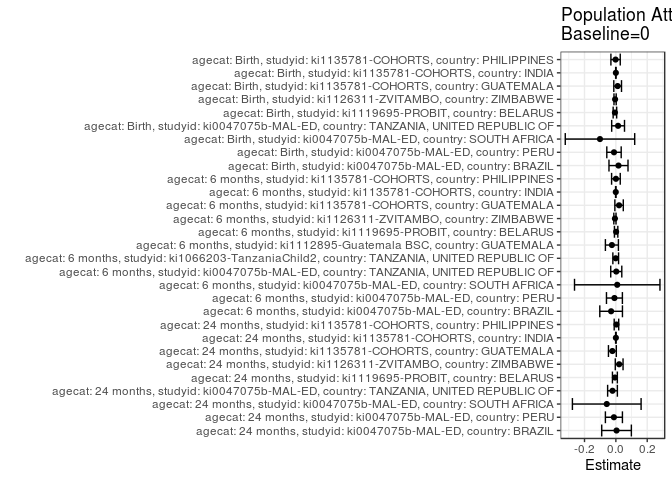

## Results Table

### Parameter: TSM

| agecat | studyid | country | intervention_level | baseline_level | estimate | ci_lower | ci_upper |
| --- | --- | --- | --- | --- | --- | --- | --- |
| Birth | ki0047075b-MAL-ED | BRAZIL | 0 | NA | 0.3871099 | 0.1970610 | 0.5771588 |
| Birth | ki0047075b-MAL-ED | BRAZIL | 1 | NA | 0.4778722 | 0.0462468 | 0.9094976 |
| Birth | ki0047075b-MAL-ED | PERU | 0 | NA | -0.0616655 | -0.1759429 | 0.0526119 |
| Birth | ki0047075b-MAL-ED | PERU | 1 | NA | -0.1949528 | -0.5862333 | 0.1963278 |
| Birth | ki0047075b-MAL-ED | SOUTH AFRICA | 0 | NA | 0.0450268 | -0.2314832 | 0.3215368 |
| Birth | ki0047075b-MAL-ED | SOUTH AFRICA | 1 | NA | -0.3057576 | -0.5561594 | -0.0553558 |
| Birth | ki0047075b-MAL-ED | TANZANIA, UNITED REPUBLIC OF | 0 | NA | 0.7790179 | 0.5756945 | 0.9823412 |
| Birth | ki0047075b-MAL-ED | TANZANIA, UNITED REPUBLIC OF | 1 | NA | 1.0583333 | 0.3116322 | 1.8050345 |
| Birth | ki1119695-PROBIT | BELARUS | 0 | NA | -1.1402584 | -1.3529476 | -0.9275691 |
| Birth | ki1119695-PROBIT | BELARUS | 1 | NA | -1.0199232 | -1.1271922 | -0.9126542 |
| Birth | ki1126311-ZVITAMBO | ZIMBABWE | 0 | NA | -0.5095634 | -0.5363536 | -0.4827733 |
| Birth | ki1126311-ZVITAMBO | ZIMBABWE | 1 | NA | -0.6057906 | -0.7247776 | -0.4868036 |
| Birth | ki1135781-COHORTS | GUATEMALA | 0 | NA | -1.0666131 | -1.1763570 | -0.9568691 |
| Birth | ki1135781-COHORTS | GUATEMALA | 1 | NA | -0.9456565 | -1.4411879 | -0.4501250 |
| Birth | ki1135781-COHORTS | INDIA | 0 | NA | -0.9764901 | -1.0121932 | -0.9407871 |
| Birth | ki1135781-COHORTS | INDIA | 1 | NA | -0.9871429 | -1.0249916 | -0.9492941 |
| Birth | ki1135781-COHORTS | PHILIPPINES | 0 | NA | -0.7359519 | -0.7929454 | -0.6789584 |
| Birth | ki1135781-COHORTS | PHILIPPINES | 1 | NA | 0.6441772 | 0.5688705 | 0.7194838 |
| 6 months | ki0047075b-MAL-ED | BRAZIL | 0 | NA | 1.0019997 | 0.8263091 | 1.1776903 |
| 6 months | ki0047075b-MAL-ED | BRAZIL | 1 | NA | 0.8110375 | 0.3284604 | 1.2936146 |
| 6 months | ki0047075b-MAL-ED | PERU | 0 | NA | 1.0635319 | 0.9366572 | 1.1904067 |
| 6 months | ki0047075b-MAL-ED | PERU | 1 | NA | 0.9948638 | 0.5746802 | 1.4150474 |
| 6 months | ki0047075b-MAL-ED | SOUTH AFRICA | 0 | NA | 0.5333199 | 0.2021321 | 0.8645078 |
| 6 months | ki0047075b-MAL-ED | SOUTH AFRICA | 1 | NA | 0.9095672 | 0.6233732 | 1.1957612 |
| 6 months | ki0047075b-MAL-ED | TANZANIA, UNITED REPUBLIC OF | 0 | NA | 0.5145258 | 0.3853273 | 0.6437243 |
| 6 months | ki0047075b-MAL-ED | TANZANIA, UNITED REPUBLIC OF | 1 | NA | 0.5925000 | -0.4882365 | 1.6732365 |
| 6 months | ki1066203-TanzaniaChild2 | TANZANIA, UNITED REPUBLIC OF | 0 | NA | 0.0807356 | 0.0260348 | 0.1354364 |
| 6 months | ki1066203-TanzaniaChild2 | TANZANIA, UNITED REPUBLIC OF | 1 | NA | 0.0637534 | -0.1458747 | 0.2733814 |
| 6 months | ki1112895-Guatemala BSC | GUATEMALA | 0 | NA | -0.0316149 | -0.1530012 | 0.0897715 |
| 6 months | ki1112895-Guatemala BSC | GUATEMALA | 1 | NA | -0.3070849 | -0.6928722 | 0.0787024 |
| 6 months | ki1119695-PROBIT | BELARUS | 0 | NA | 0.5773587 | 0.5167649 | 0.6379525 |
| 6 months | ki1119695-PROBIT | BELARUS | 1 | NA | 0.4529282 | 0.3819027 | 0.5239536 |
| 6 months | ki1126311-ZVITAMBO | ZIMBABWE | 0 | NA | 0.3110188 | 0.2839646 | 0.3380730 |
| 6 months | ki1126311-ZVITAMBO | ZIMBABWE | 1 | NA | 0.1714574 | 0.0602811 | 0.2826337 |
| 6 months | ki1135781-COHORTS | GUATEMALA | 0 | NA | 0.1715739 | 0.0948664 | 0.2482815 |
| 6 months | ki1135781-COHORTS | GUATEMALA | 1 | NA | 0.2554898 | -0.3178691 | 0.8288488 |
| 6 months | ki1135781-COHORTS | INDIA | 0 | NA | -0.7098951 | -0.7430287 | -0.6767615 |
| 6 months | ki1135781-COHORTS | INDIA | 1 | NA | -1.0322222 | -1.0700926 | -0.9943519 |
| 6 months | ki1135781-COHORTS | PHILIPPINES | 0 | NA | -0.2940540 | -0.3452082 | -0.2428998 |
| 6 months | ki1135781-COHORTS | PHILIPPINES | 1 | NA | -0.1231716 | -0.1690077 | -0.0773356 |
| 24 months | ki0047075b-MAL-ED | BRAZIL | 0 | NA | 0.4422968 | 0.2313644 | 0.6532292 |
| 24 months | ki0047075b-MAL-ED | BRAZIL | 1 | NA | 0.3389126 | -0.3977462 | 1.0755713 |
| 24 months | ki0047075b-MAL-ED | PERU | 0 | NA | 0.1323596 | 0.0085261 | 0.2561931 |
| 24 months | ki0047075b-MAL-ED | PERU | 1 | NA | 0.1468471 | -0.2794885 | 0.5731827 |
| 24 months | ki0047075b-MAL-ED | SOUTH AFRICA | 0 | NA | 0.4847953 | 0.2270185 | 0.7425721 |
| 24 months | ki0047075b-MAL-ED | SOUTH AFRICA | 1 | NA | 0.5985168 | 0.3414953 | 0.8555382 |
| 24 months | ki0047075b-MAL-ED | TANZANIA, UNITED REPUBLIC OF | 0 | NA | 0.0715385 | -0.0529948 | 0.1960717 |
| 24 months | ki0047075b-MAL-ED | TANZANIA, UNITED REPUBLIC OF | 1 | NA | -0.6933333 | -1.6135001 | 0.2268334 |
| 24 months | ki1119695-PROBIT | BELARUS | 0 | NA | 0.6925281 | 0.5744321 | 0.8106241 |
| 24 months | ki1119695-PROBIT | BELARUS | 1 | NA | 0.2599285 | 0.0468853 | 0.4729717 |
| 24 months | ki1126311-ZVITAMBO | ZIMBABWE | 0 | NA | -1.1991479 | -1.3078878 | -1.0904080 |
| 24 months | ki1126311-ZVITAMBO | ZIMBABWE | 1 | NA | -0.8921373 | -1.1162282 | -0.6680463 |
| 24 months | ki1135781-COHORTS | GUATEMALA | 0 | NA | -0.2574928 | -0.3161731 | -0.1988124 |
| 24 months | ki1135781-COHORTS | GUATEMALA | 1 | NA | -0.6537838 | -0.9321356 | -0.3754320 |
| 24 months | ki1135781-COHORTS | INDIA | 0 | NA | -0.6594835 | -0.6934635 | -0.6255034 |
| 24 months | ki1135781-COHORTS | INDIA | 1 | NA | -0.6300000 | -0.6887577 | -0.5712423 |
| 24 months | ki1135781-COHORTS | PHILIPPINES | 0 | NA | -0.6137726 | -0.6539052 | -0.5736400 |
| 24 months | ki1135781-COHORTS | PHILIPPINES | 1 | NA | 0.6671813 | 0.6417703 | 0.6925923 |

### Parameter: E(Y)

| agecat | studyid | country | intervention_level | baseline_level | estimate | ci_lower | ci_upper |
| --- | --- | --- | --- | --- | --- | --- | --- |
| Birth | ki0047075b-MAL-ED | BRAZIL | NA | NA | 0.4038798 | 0.2296279 | 0.5781316 |
| Birth | ki0047075b-MAL-ED | PERU | NA | NA | -0.0735842 | -0.1836203 | 0.0364518 |
| Birth | ki0047075b-MAL-ED | SOUTH AFRICA | NA | NA | -0.0562791 | -0.2000837 | 0.0875255 |
| Birth | ki0047075b-MAL-ED | TANZANIA, UNITED REPUBLIC OF | NA | NA | 0.7932203 | 0.5962220 | 0.9902187 |
| Birth | ki1119695-PROBIT | BELARUS | NA | NA | -1.1463469 | -1.3562674 | -0.9364264 |
| Birth | ki1126311-ZVITAMBO | ZIMBABWE | NA | NA | -0.5145122 | -0.5404077 | -0.4886167 |
| Birth | ki1135781-COHORTS | GUATEMALA | NA | NA | -1.0552243 | -1.1617873 | -0.9486614 |
| Birth | ki1135781-COHORTS | INDIA | NA | NA | -0.9765068 | -1.0113301 | -0.9416835 |
| Birth | ki1135781-COHORTS | PHILIPPINES | NA | NA | -0.7377902 | -0.7844819 | -0.6910986 |
| 6 months | ki0047075b-MAL-ED | BRAZIL | NA | NA | 0.9717225 | 0.8073791 | 1.1360658 |
| 6 months | ki0047075b-MAL-ED | PERU | NA | NA | 1.0543956 | 0.9326967 | 1.1760945 |
| 6 months | ki0047075b-MAL-ED | SOUTH AFRICA | NA | NA | 0.5420735 | 0.3899459 | 0.6942011 |
| 6 months | ki0047075b-MAL-ED | TANZANIA, UNITED REPUBLIC OF | NA | NA | 0.5170513 | 0.3872178 | 0.6468847 |
| 6 months | ki1066203-TanzaniaChild2 | TANZANIA, UNITED REPUBLIC OF | NA | NA | 0.0797577 | 0.0268998 | 0.1326156 |
| 6 months | ki1112895-Guatemala BSC | GUATEMALA | NA | NA | -0.0568833 | -0.1722874 | 0.0585208 |
| 6 months | ki1119695-PROBIT | BELARUS | NA | NA | 0.5789633 | 0.5190130 | 0.6389137 |
| 6 months | ki1126311-ZVITAMBO | ZIMBABWE | NA | NA | 0.3050103 | 0.2788985 | 0.3311222 |
| 6 months | ki1135781-COHORTS | GUATEMALA | NA | NA | 0.1920134 | 0.1173734 | 0.2666534 |
| 6 months | ki1135781-COHORTS | INDIA | NA | NA | -0.7104795 | -0.7428008 | -0.6781581 |
| 6 months | ki1135781-COHORTS | PHILIPPINES | NA | NA | -0.2936948 | -0.3352840 | -0.2521057 |
| 24 months | ki0047075b-MAL-ED | BRAZIL | NA | NA | 0.4466272 | 0.2416144 | 0.6516401 |
| 24 months | ki0047075b-MAL-ED | PERU | NA | NA | 0.1199005 | -0.0000331 | 0.2398341 |
| 24 months | ki0047075b-MAL-ED | SOUTH AFRICA | NA | NA | 0.4267017 | 0.3074751 | 0.5459283 |
| 24 months | ki0047075b-MAL-ED | TANZANIA, UNITED REPUBLIC OF | NA | NA | 0.0500935 | -0.0748234 | 0.1750103 |
| 24 months | ki1119695-PROBIT | BELARUS | NA | NA | 0.6863435 | 0.5745700 | 0.7981170 |
| 24 months | ki1126311-ZVITAMBO | ZIMBABWE | NA | NA | -1.1781043 | -1.2781256 | -1.0780830 |
| 24 months | ki1135781-COHORTS | GUATEMALA | NA | NA | -0.2796964 | -0.3351582 | -0.2242346 |
| 24 months | ki1135781-COHORTS | INDIA | NA | NA | -0.6594122 | -0.6925753 | -0.6262491 |
| 24 months | ki1135781-COHORTS | PHILIPPINES | NA | NA | -0.6100579 | -0.6471813 | -0.5729344 |

### Parameter: ATE

| agecat | studyid | country | intervention_level | baseline_level | estimate | ci_lower | ci_upper |
| --- | --- | --- | --- | --- | --- | --- | --- |
| Birth | ki0047075b-MAL-ED | BRAZIL | 0 | 0 | 0.0000000 | 0.0000000 | 0.0000000 |
| Birth | ki0047075b-MAL-ED | BRAZIL | 1 | 0 | 0.0907623 | -0.3795536 | 0.5610782 |
| Birth | ki0047075b-MAL-ED | PERU | 0 | 0 | 0.0000000 | 0.0000000 | 0.0000000 |
| Birth | ki0047075b-MAL-ED | PERU | 1 | 0 | -0.1332873 | -0.5416371 | 0.2750625 |
| Birth | ki0047075b-MAL-ED | SOUTH AFRICA | 0 | 0 | 0.0000000 | 0.0000000 | 0.0000000 |
| Birth | ki0047075b-MAL-ED | SOUTH AFRICA | 1 | 0 | -0.3507844 | -0.7255915 | 0.0240228 |
| Birth | ki0047075b-MAL-ED | TANZANIA, UNITED REPUBLIC OF | 0 | 0 | 0.0000000 | 0.0000000 | 0.0000000 |
| Birth | ki0047075b-MAL-ED | TANZANIA, UNITED REPUBLIC OF | 1 | 0 | 0.2793155 | -0.4945728 | 1.0532037 |
| Birth | ki1119695-PROBIT | BELARUS | 0 | 0 | 0.0000000 | 0.0000000 | 0.0000000 |
| Birth | ki1119695-PROBIT | BELARUS | 1 | 0 | 0.1203352 | -0.0783613 | 0.3190316 |
| Birth | ki1126311-ZVITAMBO | ZIMBABWE | 0 | 0 | 0.0000000 | 0.0000000 | 0.0000000 |
| Birth | ki1126311-ZVITAMBO | ZIMBABWE | 1 | 0 | -0.0962272 | -0.2181224 | 0.0256680 |
| Birth | ki1135781-COHORTS | GUATEMALA | 0 | 0 | 0.0000000 | 0.0000000 | 0.0000000 |
| Birth | ki1135781-COHORTS | GUATEMALA | 1 | 0 | 0.1209566 | -0.3860048 | 0.6279180 |
| Birth | ki1135781-COHORTS | INDIA | 0 | 0 | 0.0000000 | 0.0000000 | 0.0000000 |
| Birth | ki1135781-COHORTS | INDIA | 1 | 0 | -0.0106527 | -0.0626838 | 0.0413784 |
| Birth | ki1135781-COHORTS | PHILIPPINES | 0 | 0 | 0.0000000 | 0.0000000 | 0.0000000 |
| Birth | ki1135781-COHORTS | PHILIPPINES | 1 | 0 | 1.3801290 | 1.2861312 | 1.4741269 |
| 6 months | ki0047075b-MAL-ED | BRAZIL | 0 | 0 | 0.0000000 | 0.0000000 | 0.0000000 |
| 6 months | ki0047075b-MAL-ED | BRAZIL | 1 | 0 | -0.1909623 | -0.7057637 | 0.3238392 |
| 6 months | ki0047075b-MAL-ED | PERU | 0 | 0 | 0.0000000 | 0.0000000 | 0.0000000 |
| 6 months | ki0047075b-MAL-ED | PERU | 1 | 0 | -0.0686682 | -0.5073457 | 0.3700094 |
| 6 months | ki0047075b-MAL-ED | SOUTH AFRICA | 0 | 0 | 0.0000000 | 0.0000000 | 0.0000000 |
| 6 months | ki0047075b-MAL-ED | SOUTH AFRICA | 1 | 0 | 0.3762473 | -0.0627951 | 0.8152897 |
| 6 months | ki0047075b-MAL-ED | TANZANIA, UNITED REPUBLIC OF | 0 | 0 | 0.0000000 | 0.0000000 | 0.0000000 |
| 6 months | ki0047075b-MAL-ED | TANZANIA, UNITED REPUBLIC OF | 1 | 0 | 0.0779742 | -1.0104576 | 1.1664060 |
| 6 months | ki1066203-TanzaniaChild2 | TANZANIA, UNITED REPUBLIC OF | 0 | 0 | 0.0000000 | 0.0000000 | 0.0000000 |
| 6 months | ki1066203-TanzaniaChild2 | TANZANIA, UNITED REPUBLIC OF | 1 | 0 | -0.0169822 | -0.2340230 | 0.2000585 |
| 6 months | ki1112895-Guatemala BSC | GUATEMALA | 0 | 0 | 0.0000000 | 0.0000000 | 0.0000000 |
| 6 months | ki1112895-Guatemala BSC | GUATEMALA | 1 | 0 | -0.2754700 | -0.6798709 | 0.1289309 |
| 6 months | ki1119695-PROBIT | BELARUS | 0 | 0 | 0.0000000 | 0.0000000 | 0.0000000 |
| 6 months | ki1119695-PROBIT | BELARUS | 1 | 0 | -0.1244306 | -0.2004604 | -0.0484007 |
| 6 months | ki1126311-ZVITAMBO | ZIMBABWE | 0 | 0 | 0.0000000 | 0.0000000 | 0.0000000 |
| 6 months | ki1126311-ZVITAMBO | ZIMBABWE | 1 | 0 | -0.1395614 | -0.2538081 | -0.0253148 |
| 6 months | ki1135781-COHORTS | GUATEMALA | 0 | 0 | 0.0000000 | 0.0000000 | 0.0000000 |
| 6 months | ki1135781-COHORTS | GUATEMALA | 1 | 0 | 0.0839159 | -0.4947393 | 0.6625710 |
| 6 months | ki1135781-COHORTS | INDIA | 0 | 0 | 0.0000000 | 0.0000000 | 0.0000000 |
| 6 months | ki1135781-COHORTS | INDIA | 1 | 0 | -0.3223272 | -0.3726461 | -0.2720082 |
| 6 months | ki1135781-COHORTS | PHILIPPINES | 0 | 0 | 0.0000000 | 0.0000000 | 0.0000000 |
| 6 months | ki1135781-COHORTS | PHILIPPINES | 1 | 0 | 0.1708824 | 0.1021083 | 0.2396564 |
| 24 months | ki0047075b-MAL-ED | BRAZIL | 0 | 0 | 0.0000000 | 0.0000000 | 0.0000000 |
| 24 months | ki0047075b-MAL-ED | BRAZIL | 1 | 0 | -0.1033842 | -0.8716377 | 0.6648693 |
| 24 months | ki0047075b-MAL-ED | PERU | 0 | 0 | 0.0000000 | 0.0000000 | 0.0000000 |
| 24 months | ki0047075b-MAL-ED | PERU | 1 | 0 | 0.0144875 | -0.4316390 | 0.4606140 |
| 24 months | ki0047075b-MAL-ED | SOUTH AFRICA | 0 | 0 | 0.0000000 | 0.0000000 | 0.0000000 |
| 24 months | ki0047075b-MAL-ED | SOUTH AFRICA | 1 | 0 | 0.1137215 | -0.2519703 | 0.4794132 |
| 24 months | ki0047075b-MAL-ED | TANZANIA, UNITED REPUBLIC OF | 0 | 0 | 0.0000000 | 0.0000000 | 0.0000000 |
| 24 months | ki0047075b-MAL-ED | TANZANIA, UNITED REPUBLIC OF | 1 | 0 | -0.7648718 | -1.6934273 | 0.1636837 |
| 24 months | ki1119695-PROBIT | BELARUS | 0 | 0 | 0.0000000 | 0.0000000 | 0.0000000 |
| 24 months | ki1119695-PROBIT | BELARUS | 1 | 0 | -0.4325996 | -0.6867846 | -0.1784146 |
| 24 months | ki1126311-ZVITAMBO | ZIMBABWE | 0 | 0 | 0.0000000 | 0.0000000 | 0.0000000 |
| 24 months | ki1126311-ZVITAMBO | ZIMBABWE | 1 | 0 | 0.3070107 | 0.0574166 | 0.5566047 |
| 24 months | ki1135781-COHORTS | GUATEMALA | 0 | 0 | 0.0000000 | 0.0000000 | 0.0000000 |
| 24 months | ki1135781-COHORTS | GUATEMALA | 1 | 0 | -0.3962910 | -0.6808665 | -0.1117155 |
| 24 months | ki1135781-COHORTS | INDIA | 0 | 0 | 0.0000000 | 0.0000000 | 0.0000000 |
| 24 months | ki1135781-COHORTS | INDIA | 1 | 0 | 0.0294835 | -0.0383923 | 0.0973592 |
| 24 months | ki1135781-COHORTS | PHILIPPINES | 0 | 0 | 0.0000000 | 0.0000000 | 0.0000000 |
| 24 months | ki1135781-COHORTS | PHILIPPINES | 1 | 0 | 1.2809539 | 1.2339438 | 1.3279640 |

### Parameter: PAR

| agecat | studyid | country | intervention_level | baseline_level | estimate | ci_lower | ci_upper |
| --- | --- | --- | --- | --- | --- | --- | --- |
| Birth | ki0047075b-MAL-ED | BRAZIL | 0 | NA | 0.0167699 | -0.0439251 | 0.0774649 |
| Birth | ki0047075b-MAL-ED | PERU | 0 | NA | -0.0119187 | -0.0578154 | 0.0339779 |
| Birth | ki0047075b-MAL-ED | SOUTH AFRICA | 0 | NA | -0.1013058 | -0.3226933 | 0.1200816 |
| Birth | ki0047075b-MAL-ED | TANZANIA, UNITED REPUBLIC OF | 0 | NA | 0.0142025 | -0.0266884 | 0.0550934 |
| Birth | ki1119695-PROBIT | BELARUS | 0 | NA | -0.0060885 | -0.0173019 | 0.0051248 |
| Birth | ki1126311-ZVITAMBO | ZIMBABWE | 0 | NA | -0.0049487 | -0.0120207 | 0.0021232 |
| Birth | ki1135781-COHORTS | GUATEMALA | 0 | NA | 0.0113888 | -0.0132148 | 0.0359924 |
| Birth | ki1135781-COHORTS | INDIA | 0 | NA | -0.0000167 | -0.0013175 | 0.0012841 |
| Birth | ki1135781-COHORTS | PHILIPPINES | 0 | NA | -0.0018383 | -0.0316168 | 0.0279402 |
| 6 months | ki0047075b-MAL-ED | BRAZIL | 0 | NA | -0.0302772 | -0.1025599 | 0.0420054 |
| 6 months | ki0047075b-MAL-ED | PERU | 0 | NA | -0.0091363 | -0.0599260 | 0.0416534 |
| 6 months | ki0047075b-MAL-ED | SOUTH AFRICA | 0 | NA | 0.0087535 | -0.2637316 | 0.2812387 |
| 6 months | ki0047075b-MAL-ED | TANZANIA, UNITED REPUBLIC OF | 0 | NA | 0.0025255 | -0.0327695 | 0.0378205 |
| 6 months | ki1066203-TanzaniaChild2 | TANZANIA, UNITED REPUBLIC OF | 0 | NA | -0.0009779 | -0.0191714 | 0.0172156 |
| 6 months | ki1112895-Guatemala BSC | GUATEMALA | 0 | NA | -0.0252684 | -0.0667839 | 0.0162471 |
| 6 months | ki1119695-PROBIT | BELARUS | 0 | NA | 0.0016046 | -0.0092579 | 0.0124671 |
| 6 months | ki1126311-ZVITAMBO | ZIMBABWE | 0 | NA | -0.0060085 | -0.0129829 | 0.0009659 |
| 6 months | ki1135781-COHORTS | GUATEMALA | 0 | NA | 0.0204395 | -0.0064564 | 0.0473353 |
| 6 months | ki1135781-COHORTS | INDIA | 0 | NA | -0.0005844 | -0.0018989 | 0.0007302 |
| 6 months | ki1135781-COHORTS | PHILIPPINES | 0 | NA | 0.0003592 | -0.0272081 | 0.0279264 |
| 24 months | ki0047075b-MAL-ED | BRAZIL | 0 | NA | 0.0043304 | -0.0902115 | 0.0988724 |
| 24 months | ki0047075b-MAL-ED | PERU | 0 | NA | -0.0124591 | -0.0667683 | 0.0418501 |
| 24 months | ki0047075b-MAL-ED | SOUTH AFRICA | 0 | NA | -0.0580936 | -0.2771384 | 0.1609512 |
| 24 months | ki0047075b-MAL-ED | TANZANIA, UNITED REPUBLIC OF | 0 | NA | -0.0214450 | -0.0525145 | 0.0096245 |
| 24 months | ki1119695-PROBIT | BELARUS | 0 | NA | -0.0061846 | -0.0218166 | 0.0094474 |
| 24 months | ki1126311-ZVITAMBO | ZIMBABWE | 0 | NA | 0.0210436 | -0.0037279 | 0.0458152 |
| 24 months | ki1135781-COHORTS | GUATEMALA | 0 | NA | -0.0222036 | -0.0472531 | 0.0028458 |
| 24 months | ki1135781-COHORTS | INDIA | 0 | NA | 0.0000712 | -0.0016263 | 0.0017687 |
| 24 months | ki1135781-COHORTS | PHILIPPINES | 0 | NA | 0.0037147 | -0.0106431 | 0.0180726 |